# Churn Analysis Mattinson

Student: Mike Mattinson

Student ID: 0 0 1 9 8 0 7 6 1

Class: Data Cleaning D206

School: WGU

Date: Cinco de Mayo, 2021

## Getting Started

### Upgrade Notebook

pip install notebook --upgrade

### Install Pandas

pip install pandas

### Install Nbextensions

pip install jupyter_contrib_nbextensions

jupyter contrib nbextension install --user

### Enable ToC2

jupyter nbextension enable ToC2/main

### Notebook Directories

jupyter notebook --generate-config

### Styles

```python
# Styling notebook
from IPython.core.display import HTML
def css_styling(f):
    styles = open("./styles/" + f, "r").read()
    print("Incorporate css styles into notebook (STO21).")
    return HTML(styles)
css_styling('custom.css')
```

```
Incorporate css styles into notebook (STO21).
```

### Define create_box_plot(source,title,height,width) Function

```python
# define a function to create box plot
def create_box_plot(source,title,height,width):
    normal = (source-source.mean())/source.std() # normalized
    fig = plt.figure(figsize =(width,height))
    ax = fig.add_subplot(111)

    # Creating axes instance
    bp = ax.boxplot(normal, patch_artist = True,
                    notch ='True', vert = 0)

    # changing color and linewidth of whiskers
    for whisker in bp['whiskers']:
        whisker.set(color ='#8B008B',
                    linewidth = 1.5,
                    linestyle =":")

    # changing color and linewidth of caps
    for cap in bp['caps']:
        cap.set(color ='#8B008B',
                linewidth = 2)

    # changing color and linewidth of medians
    for median in bp['medians']:
        median.set(color ='red',
                   linewidth = 3)

    # changing style of fliers
    for flier in bp['fliers']:
        flier.set(marker ='D',
                  color ='#e7298a',
                  alpha = 0.5)

    ax.set_yticklabels(source.columns) # x-axis labels
    plt.title(title)
    ax.get_xaxis().tick_bottom() # remove bottom ticks
    ax.get_yaxis().tick_left() # remove left ticks
    plt.show(bp) # display plot
```

### Define get_outliers(c) Function

```python
# define get_outliers function
def get_outliers(c):
    temp = 'z'+c
    cols = [c,temp,'Churn']
    df[temp] = stats.zscore(df[c])
    df_temp = df[cols].query('abs(' + temp + ') > 3')
    df.drop(columns = temp, inplace=True)
    return(df_temp.sort_values(by=[temp], ascending=False))
```

## Part I: Research Question

### A. Describe question

Summary from problem's associated dictionary file (WGU21):

In the telecommunications industry, customers can choose from multiple service providers and actively switch from one provider to another. Customer “churn” is defined as the percentage of customers who stopped using a provider’s product or service during a certain time frame. In this highly competitive market, some telecommunications industries can experience average annual churn rates as high as 25 percent. Given that it costs 10 times more to acquire a new customer than to retain an existing one, customer retention has now become even more important than customer acquisition. For many providers, retaining highly profitable customers is the number one business goal. To reduce customer churn, telecommunications companies need to predict which customers are at high risk of churn. You are an analyst on a team of analysts in a popular telecommunications company, which serves customers in all regions of the United States. You have been asked to clean the raw data set in preparation to explore the data, identify trends, and compare key metrics.

Question: Which factor(s) are most important in predicting churn? In other words, what action(s) can minimize churn and increase profit? Here is a list of some of the possible factors affecting churn:

- pay too much...
- pay too much and have problems...
- pay too much and have service interuptions...
- pay too much and have problems and call in to tech support...
- maybe not techie enough to take care of their own problems...
- lower income and pay too much...
- higher income might not care how much they pay...
- pay too much and getting too many marketing emails...
- getting too many marketing emails...

### B. Describe variables

#### Import Packages

First thing before going too much further, import all of the packages to be used throughout the notebook.

```python
# import required libraries
import numpy as np
import pandas as pd
import matplotlib.pyplot as plt
from sklearn import preprocessing
import seaborn as sns
from sklearn.decomposition import PCA
import scipy.stats as stats
```

#### Setup Dataframe

```python
# use df.info() to list variables, counts and datatypes
df = pd.read_csv('churn_raw_data.csv')
df.info() # show types and counts
```

```
<class 'pandas.core.frame.DataFrame'>
RangeIndex: 10000 entries, 0 to 9999
Data columns (total 52 columns):
 #   Column                Non-Null Count  Dtype
---  ------                --------------  -----
 0   Unnamed: 0            10000 non-null  int64
 1   CaseOrder             10000 non-null  int64
 2   Customer_id           10000 non-null  object
 3   Interaction           10000 non-null  object
 4   City                  10000 non-null  object
 5   State                 10000 non-null  object
 6   County                10000 non-null  object
 7   Zip                   10000 non-null  int64
 8   Lat                   10000 non-null  float64
 9   Lng                   10000 non-null  float64
```

[output cut: 44 more lines]

#### Find Missing Data

Looking at the data, you can see the following columns are missing data, there are null values; the non-null count is less than 10,000:

```python
missing = df[df.columns[df.isna().any()]].columns
df_missing = df[missing]
df_missing.info()
```

```
<class 'pandas.core.frame.DataFrame'>
RangeIndex: 10000 entries, 0 to 9999
Data columns (total 8 columns):
 #   Column             Non-Null Count  Dtype
---  ------             --------------  -----
 0   Children           7505 non-null   float64
 1   Age                7525 non-null   float64
 2   Income             7510 non-null   float64
 3   Techie             7523 non-null   object
 4   Phone              8974 non-null   object
 5   TechSupport        9009 non-null   object
 6   Tenure             9069 non-null   float64
 7   Bandwidth_GB_Year  8979 non-null   float64
dtypes: float64(5), object(3)
memory usage: 625.1+ KB
```

#### Explore Numerical Data

Also, you can see there are both numeric data and categorical data. Here is the numeric data:

```python
# setup as variable to be used again later
df_num = df.select_dtypes(include='number')
df_num.info() # display types and counts
```

```
<class 'pandas.core.frame.DataFrame'>
RangeIndex: 10000 entries, 0 to 9999
Data columns (total 24 columns):
 #   Column                Non-Null Count  Dtype
---  ------                --------------  -----
 0   Unnamed: 0            10000 non-null  int64
 1   CaseOrder             10000 non-null  int64
 2   Zip                   10000 non-null  int64
 3   Lat                   10000 non-null  float64
 4   Lng                   10000 non-null  float64
 5   Population            10000 non-null  int64
 6   Children              7505 non-null   float64
 7   Age                   7525 non-null   float64
 8   Income                7510 non-null   float64
 9   Outage_sec_perweek    10000 non-null  float64
```

[output cut: 16 more lines]

#### Explore Categorical Data

And, here is the categorical data:

```python
# setup as variable to be used again later
df_cat = df.select_dtypes(include='object')
df_cat.info()
```

```
<class 'pandas.core.frame.DataFrame'>
RangeIndex: 10000 entries, 0 to 9999
Data columns (total 28 columns):
 #   Column            Non-Null Count  Dtype
---  ------            --------------  -----
 0   Customer_id       10000 non-null  object
 1   Interaction       10000 non-null  object
 2   City              10000 non-null  object
 3   State             10000 non-null  object
 4   County            10000 non-null  object
 5   Area              10000 non-null  object
 6   Timezone          10000 non-null  object
 7   Job               10000 non-null  object
 8   Education         10000 non-null  object
 9   Employment        10000 non-null  object
```

[output cut: 20 more lines]

```python
# show categorical columns with null values
df_cat[df_cat.columns[df_cat.isna().any()]].columns
```

```
Index(['Techie', 'Phone', 'TechSupport'], dtype='object')
```

#### Customer Account Data

Purposefully excluding the 'Customer_id' column from any of the following lists. Plan to re-index data using the 'Customer_id' and then these lists wouldn't work if they contain 'Customer_id'.

```python
# setup customer account data
account = [
    'Contract',
    'PaperlessBilling',
    'PaymentMethod',
    'Tenure',
    'MonthlyCharge',
    'Bandwidth_GB_Year',
    ]
df[account].iloc[0] # show a record
```

```
Contract                            One year
PaperlessBilling                         Yes
PaymentMethod        Credit Card (automatic)
Tenure                               6.79551
MonthlyCharge                         171.45
Bandwidth_GB_Year                    904.536
Name: 0, dtype: object
```

#### Customer Demographics Data

```python
# setup customer demographics data
demographics = [
    'City',
    'State',
    'County',
    'Zip',
    'Lat',
    'Lng',
    'Population',
    'Area',
    'Timezone',
    'Job',
    'Children',
    'Age',
    'Education',
    'Employment',
    'Income',
    'Marital',
    'Gender',
    ]
df[demographics].info() # show data types and counts
```

```
<class 'pandas.core.frame.DataFrame'>
RangeIndex: 10000 entries, 0 to 9999
Data columns (total 17 columns):
 #   Column      Non-Null Count  Dtype
---  ------      --------------  -----
 0   City        10000 non-null  object
 1   State       10000 non-null  object
 2   County      10000 non-null  object
 3   Zip         10000 non-null  int64
 4   Lat         10000 non-null  float64
 5   Lng         10000 non-null  float64
 6   Population  10000 non-null  int64
 7   Area        10000 non-null  object
 8   Timezone    10000 non-null  object
 9   Job         10000 non-null  object
 10  Children    7505 non-null   float64
 11  Age         7525 non-null   float64
 12  Education   10000 non-null  object
 13  Employment  10000 non-null  object
 14  Income      7510 non-null   float64
 15  Marital     10000 non-null  object
 16  Gender      10000 non-null  object
dtypes: float64(5), int64(2), object(10)
memory usage: 1.3+ MB
```

#### Customer Services Data

```python
# setup customer services data list
services = [
    'Phone',
    'Port_modem',
    'Tablet',
    'InternetService',
    'Multiple',
    'OnlineSecurity',
    'OnlineBackup',
    'DeviceProtection',
    'TechSupport',
    'StreamingTV',
    'StreamingMovies',
    'OnlineBackup',
    ]
df[services].info() # show data types and counts
```

```
<class 'pandas.core.frame.DataFrame'>
RangeIndex: 10000 entries, 0 to 9999
Data columns (total 12 columns):
 #   Column            Non-Null Count  Dtype
---  ------            --------------  -----
 0   Phone             8974 non-null   object
 1   Port_modem        10000 non-null  object
 2   Tablet            10000 non-null  object
 3   InternetService   10000 non-null  object
 4   Multiple          10000 non-null  object
 5   OnlineSecurity    10000 non-null  object
 6   OnlineBackup      10000 non-null  object
 7   DeviceProtection  10000 non-null  object
 8   TechSupport       9009 non-null   object
 9   StreamingTV       10000 non-null  object
 10  StreamingMovies   10000 non-null  object
 11  OnlineBackup      10000 non-null  object
dtypes: object(12)
memory usage: 937.6+ KB
```

#### Customer Problems

```python
# setup customer problem data
problems = [
    'Contacts',
    'Outage_sec_perweek',
    'Email',
    'Yearly_equip_failure',
    ]
df[problems].describe().round(2) # show descriptive stats
```

|  | Contacts | Outage_sec_perweek | Email | Yearly_equip_failure |
| --- | --- | --- | --- | --- |
| count | 10000.00 | 10000.00 | 10000.00 | 10000.00 |
| mean | 0.99 | 11.45 | 12.02 | 0.40 |
| std | 0.99 | 7.03 | 3.03 | 0.64 |
| min | 0.00 | -1.35 | 1.00 | 0.00 |
| 25% | 0.00 | 8.05 | 10.00 | 0.00 |
| 50% | 1.00 | 10.20 | 12.00 | 0.00 |
| 75% | 2.00 | 12.49 | 14.00 | 1.00 |
| max | 7.00 | 47.05 | 23.00 | 6.00 |

```python
df['Contacts'].count()
```

```
10000
```

```python
df[problems].info()
```

```
<class 'pandas.core.frame.DataFrame'>
RangeIndex: 10000 entries, 0 to 9999
Data columns (total 4 columns):
 #   Column                Non-Null Count  Dtype
---  ------                --------------  -----
 0   Contacts              10000 non-null  int64
 1   Outage_sec_perweek    10000 non-null  float64
 2   Email                 10000 non-null  int64
 3   Yearly_equip_failure  10000 non-null  int64
dtypes: float64(1), int64(3)
memory usage: 312.6 KB
```

#### Customer Survey

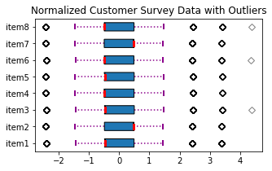

```python
# setup customer survey data
survey = [
    'item1',
    'item2',
    'item3',
    'item4',
    'item5',
    'item6',
    'item7',
    'item8',
    ]
df_survey = df[survey]
source = df_survey
title = 'Normalized Customer Survey Data with Outliers'
create_box_plot(source,title,3,5)
```

## Part II: Data-Cleaning Plan

### C. Explain plan

1. Propose a plan that includes the relevant techniques and specific steps needed to identify anomalies in the data set.
2. Justify your approach for assessing the quality of the data, include: characteristics of the data being assessed, and the approach used to assess the quality.
3. Justify your selected programming language and any libraries and packages that will support the data-cleaning process.
4. Provide the code you will use to identify the anomalies in the data.

## Part III: Data Cleaning

### Create dataframe

The datafram 'df' was created in section 2.2.

```python
# use shape to scope of data
df.shape
```

```
(10000, 52)
```

The dataframe has been successfully created with 10,000 rows and 52 attributes.

### Unique Index

It looks like the col 'Unnamed: 0' is duplicate with col 'CaseOrder'. I will keep col 'CaseOrder' in case I end up resorting and want to put the data back in its orginal order. It looks like col 'Customer_id' is a good candidate for being a unique row index. I plan on completing the following tasks:

1. Drop duplicate 'Unnamed: 0' col
2. Keep 'CaseOrder' as original sort order
3. Set new index using existing 'Customer_id' col

```python
# Drop duplicate col 'Unnamed: 0'
if 'Unnamed: 0' in df.columns:
    df.drop(columns = 'Unnamed: 0', inplace=True)
```

Because the index we want to use is already in the data, we can use df.set_index() instead of df.reindex()

```python
# set new index using existing 'Customer_id'
#if 'Customer_id' in df.columns:
#    df.set_index('Customer_id', inplace=True)
df.index
```

```
RangeIndex(start=0, stop=10000, step=1)
```

### Remove Unwanted Data

Looks like col 'Interaction' is related to customer transactions and can be removed for the purpose of this analysis. That will be the only unwanted data removed, keep everything else.

```python
# Drop unwanted col 'Interaction'
if 'Interaction' in df.columns:
    df.drop(columns = 'Interaction', inplace=True)
df.columns
```

```
Index(['CaseOrder', 'Customer_id', 'City', 'State', 'County', 'Zip', 'Lat',
       'Lng', 'Population', 'Area', 'Timezone', 'Job', 'Children', 'Age',
       'Education', 'Employment', 'Income', 'Marital', 'Gender', 'Churn',
       'Outage_sec_perweek', 'Email', 'Contacts', 'Yearly_equip_failure',
       'Techie', 'Contract', 'Port_modem', 'Tablet', 'InternetService',
       'Phone', 'Multiple', 'OnlineSecurity', 'OnlineBackup',
       'DeviceProtection', 'TechSupport', 'StreamingTV', 'StreamingMovies',
       'PaperlessBilling', 'PaymentMethod', 'Tenure', 'MonthlyCharge',
       'Bandwidth_GB_Year', 'item1', 'item2', 'item3', 'item4', 'item5',
       'item6', 'item7', 'item8'],
      dtype='object')
```

```python
df.shape
```

```
(10000, 50)
```

### Find/Eliminate Duplicate Data

```python
# look for duplicate data - looking for zero rows
df[df.duplicated()]
```

|  | CaseOrder | Customer_id | City | State | County | Zip | Lat | Lng | Population | Area | ... | MonthlyCharge | Bandwidth_GB_Year | item1 | item2 | item3 | item4 | item5 | item6 | item7 | item8 |
| --- | --- | --- | --- | --- | --- | --- | --- | --- | --- | --- | --- | --- | --- | --- | --- | --- | --- | --- | --- | --- | --- |

0 rows × 50 columns

```python
# check if any cols are duplicated - Looking for False
df.columns.duplicated().any()
```

```
False
```

```python
# check if any rows are duplicated - looing for False
df.duplicated().any()
```

```
False
```

### Identify Missing Data

```python
missing = df[df.columns[df.isna().any()]].columns
df_missing = df[missing]
df_missing.info()
```

```
<class 'pandas.core.frame.DataFrame'>
RangeIndex: 10000 entries, 0 to 9999
Data columns (total 8 columns):
 #   Column             Non-Null Count  Dtype
---  ------             --------------  -----
 0   Children           7505 non-null   float64
 1   Age                7525 non-null   float64
 2   Income             7510 non-null   float64
 3   Techie             7523 non-null   object
 4   Phone              8974 non-null   object
 5   TechSupport        9009 non-null   object
 6   Tenure             9069 non-null   float64
 7   Bandwidth_GB_Year  8979 non-null   float64
dtypes: float64(5), object(3)
memory usage: 625.1+ KB
```

### Mitigate Missing Data

NOTE. Don't use df.dropna(). That would remove any row with null values, we would be throwing out too much data. Instead, we will go through each column and find the best method of replacing the data, or if possible, we can leave the data null.

```python
# fill null values for missing numerical data
df['Children'].fillna(0, inplace=True)
df['Age'].fillna(df['Age'].mean(), inplace=True)
df['Income'].fillna(df['Income'].mean(), inplace=True)
df['Bandwidth_GB_Year'].fillna(df['Bandwidth_GB_Year'].mean(), inplace=True)
df['Tenure'].fillna(df['Tenure'].mean(), inplace=True)
```

```python
# fill null values for missing categorical data
df['Techie'].fillna('No', inplace=True)
df['Phone'].fillna('No', inplace=True)
df['TechSupport'].fillna('No', inplace=True)
```

```python
# are there any remaining null items - Looking for False
df.isnull().any().any()
```

```
False
```

Conclusion: No remaining null items. All 10,000 rows contain valid data.

### Visualize Numeric Data

NOTE. The following visualization does not work if there are any null values in the data. So, it is important to complete section 4.6 and 4.7 above before creating this plot.

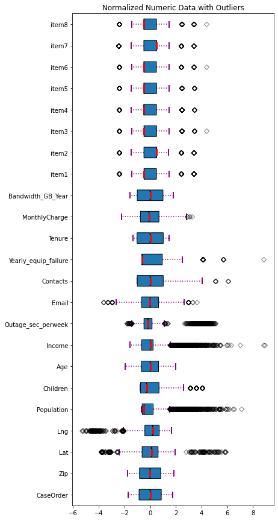

```python
# explore numeric data for outliers
source = df.select_dtypes(include='number') # numerical
title = 'Normalized Numeric Data with Outliers'
create_box_plot(source,title,15,6)
```

### Mitigate Outliers

```python
# consider outliers...
get_outliers('Email')
```

|  | Email | zEmail | Churn |
| --- | --- | --- | --- |
| 1473 | 23 | 3.630178 | Yes |
| 1746 | 22 | 3.299681 | No |
| 9475 | 22 | 3.299681 | Yes |
| 795 | 2 | -3.310257 | Yes |
| 1152 | 2 | -3.310257 | Yes |
| 1399 | 2 | -3.310257 | Yes |
| 7408 | 2 | -3.310257 | No |
| 8948 | 2 | -3.310257 | Yes |
| 9248 | 2 | -3.310257 | No |
| 1381 | 1 | -3.640754 | No |
| 6320 | 1 | -3.640754 | No |
| 8365 | 1 | -3.640754 | No |

### D. Summarize process

1. Describe the findings, including all anomalies, from the implementation of the data-cleaning plan from part C.
2. Justify your methods for mitigating each type of discovered anomaly in the data set.
3. Summarize the outcome from the implementation of each data-cleaning step.
4. Provide the code used to mitigate anomalies.
5. Provide a copy of the cleaned data set.
6. Summarize the limitations of the data-cleaning process.
7. Discuss how the limitations in part D6 affect the analysis of the question or decision from part A.

```python
df_cat = df.select_dtypes(include='object')
df_cat.info()
```

```
<class 'pandas.core.frame.DataFrame'>
RangeIndex: 10000 entries, 0 to 9999
Data columns (total 27 columns):
 #   Column            Non-Null Count  Dtype
---  ------            --------------  -----
 0   Customer_id       10000 non-null  object
 1   City              10000 non-null  object
 2   State             10000 non-null  object
 3   County            10000 non-null  object
 4   Area              10000 non-null  object
 5   Timezone          10000 non-null  object
 6   Job               10000 non-null  object
 7   Education         10000 non-null  object
 8   Employment        10000 non-null  object
 9   Marital           10000 non-null  object
```

[output cut: 19 more lines]

```python
#df['State'].value_counts()
```

#### Provide copy of cleaned data

```python
# export clean data to csv file
df.to_csv('churn_clean_data.csv', index = False)
```

## E. Apply PCA

E. Apply principal component analysis (PCA) to identify the significant features of the data set by doing the following:

1. List the principal components in the data set.
2. Describe how you identified the principal components of the data set.
3. Describe how the organization can benefit from the results of the PCA

### Convert Target to Numeric

```python
# convert target variable 'Churn' to numeric
df['Churn_num'] = df['Churn'].astype('category').cat.codes
```

### Correlation Matrix

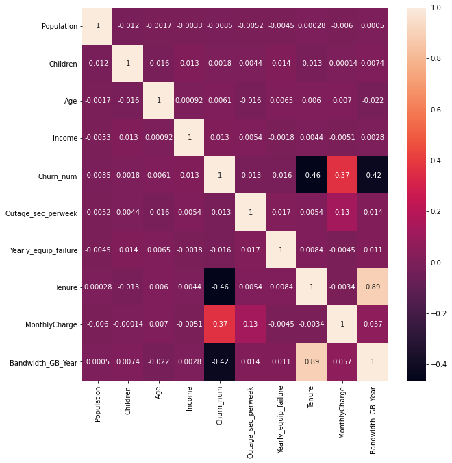

```python
df_heatmap = df[['Population', 'Children','Age','Income','Churn_num',
            'Outage_sec_perweek','Yearly_equip_failure',
            'Tenure','MonthlyCharge','Bandwidth_GB_Year']]
plt.figure(figsize=(10,10))
sns.heatmap(df_heatmap.corr(), annot=True, annot_kws={"size":10})
```

There is a positive correlation between 'Churn' and 'MonthlyCharge'.

There is a negative correlation between 'Churn' and ['Tenure', 'Bandwidth_GB_Year']

### Create Numeric dataframe

```python
# create latest data set of numeric cols
df_num = df.select_dtypes(include='number')
```

```python
df_num.columns
```

```
Index(['CaseOrder', 'Zip', 'Lat', 'Lng', 'Population', 'Children', 'Age',
       'Income', 'Outage_sec_perweek', 'Email', 'Contacts',
       'Yearly_equip_failure', 'Tenure', 'MonthlyCharge', 'Bandwidth_GB_Year',
       'item1', 'item2', 'item3', 'item4', 'item5', 'item6', 'item7', 'item8',
       'Churn_num'],
      dtype='object')
```

### Histogram with Target Overlay

Some of the data doesn't look like it will have any coorelation, e.g. 'CaseOrder', 'Lat', 'Lng', etc. Consider all data and choose which data will be dropped before moving on.

```python
target = 'Churn'
def plot_overlay(target,c,height,width):
    df.groupby([c,target]).size().unstack().plot(kind='bar', stacked=True, figsize=(width,height))
    print(pd.crosstab(df[target],
                        df[c],
                    margins = True))

# for some reason, the for loop didn't work
# too many figures all at once...
# we'll have to run them one at a time...bummer...
```

```
Employment  Full Time  Part Time  Retired  Student  Unemployed    All
Churn
No               4405        779      746      702         718   7350
Yes              1587        263      265      262         273   2650
All              5992       1042     1011      964         991  10000
```

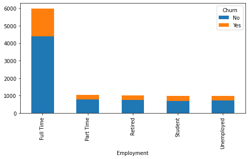

```python
plot_overlay(target,'Employment',4,8)
```

```
State  AK   AL   AR   AZ   CA   CO  CT  DC  DE   FL  ...   TN   TX  UT   VA  \
Churn                                                ...
No     54  139  132   83  388  117  46   7  15  253  ...  133  430  49  206
Yes    23   42   44   29  138   38  25   7   6   71  ...   52  173  17   79
All    77  181  176  112  526  155  71  14  21  324  ...  185  603  66  285

State  VT   WA   WI   WV  WY    All
Churn
No     61  114  160  170  32   7350
Yes    23   61   68   77  11   2650
All    84  175  228  247  43  10000

[3 rows x 53 columns]
```

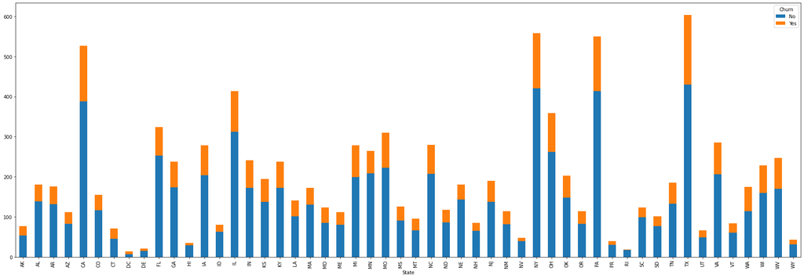

```python
plot_overlay(target,'State',10,30)
```

```
Contract  Month-to-month  One year  Two Year    All
Churn
No                  3422      1795      2133   7350
Yes                 2034       307       309   2650
All                 5456      2102      2442  10000
```

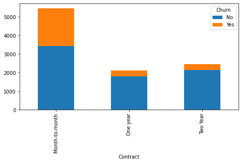

```python
plot_overlay(target,'Contract',4,8)
```

```
Gender  Female  Male  Prefer not to answer    All
Churn
No        3753  3425                   172   7350
Yes       1272  1319                    59   2650
All       5025  4744                   231  10000
```

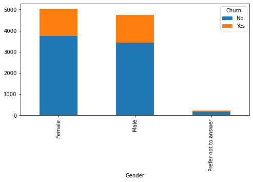

```python
plot_overlay(target,'Gender',4,8)
```

```
Techie    No   Yes    All
Churn
No      6520   830   7350
Yes     2223   427   2650
All     8743  1257  10000
```

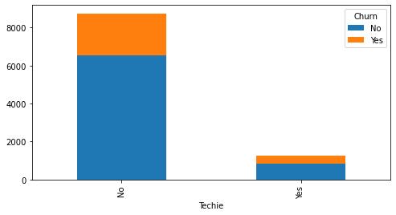

```python
plot_overlay(target,'Techie',4,8)
```

```
Port_modem    No   Yes    All
Churn
No          3815  3535   7350
Yes         1351  1299   2650
All         5166  4834  10000
```

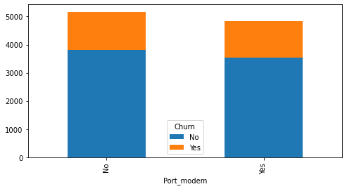

```python
plot_overlay(target,'Port_modem',4,8)
```

```
Tablet    No   Yes    All
Churn
No      5146  2204   7350
Yes     1863   787   2650
All     7009  2991  10000
```

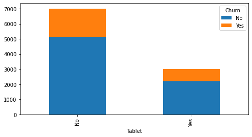

```python
plot_overlay(target,'Tablet',4,8)
```

```
InternetService   DSL  Fiber Optic  None    All
Churn
No               2349         3368  1633   7350
Yes              1114         1040   496   2650
All              3463         4408  2129  10000
```

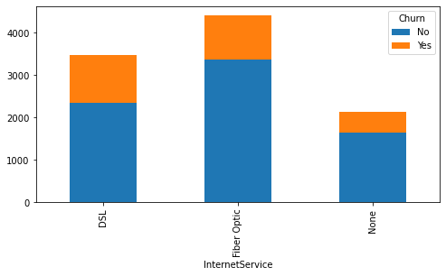

```python
plot_overlay(target,'InternetService',4,8)
```

```
Phone    No   Yes    All
Churn
No     1351  5999   7350
Yes     521  2129   2650
All    1872  8128  10000
```

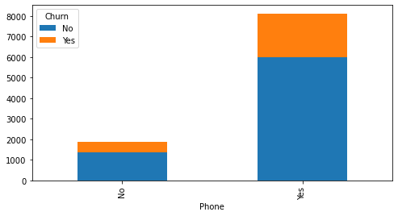

```python
plot_overlay(target,'Phone',4,8)
```

```
TechSupport    No   Yes    All
Churn
No           4911  2439   7350
Yes          1715   935   2650
All          6626  3374  10000
```

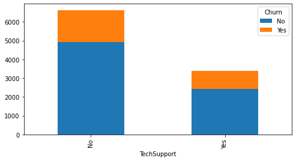

```python
plot_overlay(target,'TechSupport',4,8)
```

```
PaymentMethod  Bank Transfer(automatic)  Credit Card (automatic)  \
Churn
No                                 1671                     1543
Yes                                 558                      540
All                                2229                     2083

PaymentMethod  Electronic Check  Mailed Check    All
Churn
No                         2435          1701   7350
Yes                         963           589   2650
All                        3398          2290  10000
```

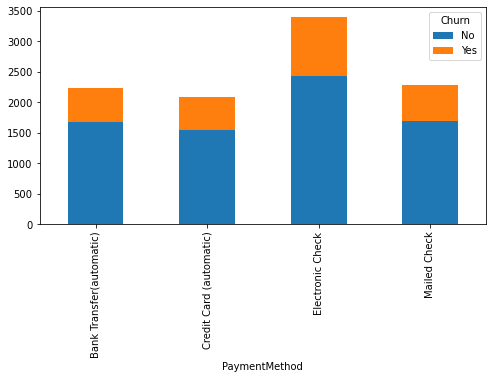

```python
plot_overlay(target,'PaymentMethod',4,8)
```

```
OnlineBackup    No   Yes    All
Churn
No            4149  3201   7350
Yes           1345  1305   2650
All           5494  4506  10000
```

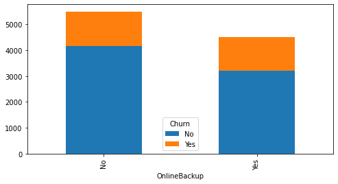

```python
plot_overlay(target,'OnlineBackup',4,8)
```

```
Email  1  2   3   4    5    6    7    8    9    10  ...   15   16   17   18  \
Churn                                               ...
No     3  2  11  26   79  138  230  409  578   796  ...  564  383  262  150
Yes    0  4   3   5   30   47   86  134  196   278  ...  215  134   89   53
All    3  6  14  31  109  185  316  543  774  1074  ...  779  517  351  203

Email   19  20  21  22  23    All
Churn
No      67  41  10   1   0   7350
Yes     33  10   2   1   1   2650
All    100  51  12   2   1  10000

[3 rows x 24 columns]
```

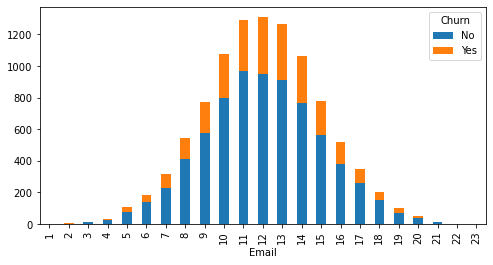

```python
plot_overlay(target,'Email',4,8)
```

```
Multiple    No   Yes    All
Churn
No        4253  3097   7350
Yes       1139  1511   2650
All       5392  4608  10000
```

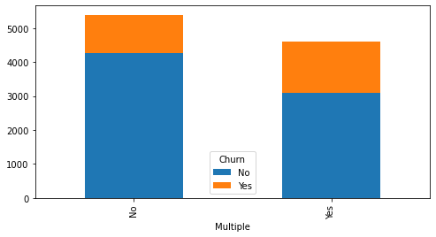

```python
plot_overlay(target,'Multiple',4,8)
```

```
Timezone  America/Anchorage  America/Boise  America/Chicago  America/Denver  \
Churn
No                       37             44             2703             408
Yes                      18             13              969             144
All                      55             57             3672             552

Timezone  America/Detroit  America/Indiana/Indianapolis  America/Indiana/Knox  \
Churn
No                    192                           137                     1
Yes                    73                            49                     0
All                   265                           186                     1

Timezone  America/Indiana/Marengo  America/Indiana/Petersburg  \
Churn
No                              1                           2
Yes                             0                           2
All                             1                           4

Timezone  America/Indiana/Tell_City  ...  America/New_York  America/Nome  \
Churn                                ...
No                                5  ...              2999             9
Yes                               1  ...              1073             3
All                               6  ...              4072            12

Timezone  America/North_Dakota/New_Salem  America/Ojinaga  America/Phoenix  \
Churn
No                                     2                1               76
Yes                                    0                0               28
All                                    2                1              104

Timezone  America/Puerto_Rico  America/Sitka  America/Toronto  \
Churn
No                         30              6                2
Yes                        10              2                3
All                        40              8                5

Timezone  Pacific/Honolulu    All
Churn
No                      29   7350
Yes                      6   2650
All                     35  10000

[3 rows x 26 columns]
```

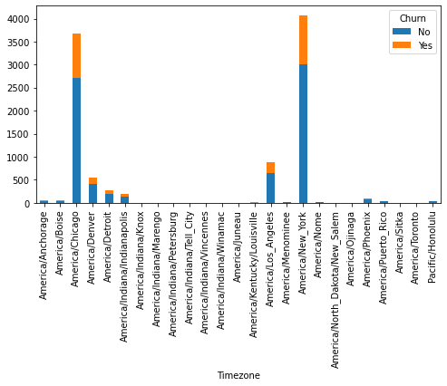

```python
plot_overlay(target,'Timezone',4,8)
```

```
Area   Rural  Suburban  Urban    All
Churn
No      2464      2473   2413   7350
Yes      863       873    914   2650
All     3327      3346   3327  10000
```

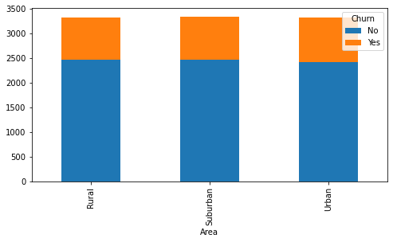

```python
plot_overlay(target,'Area',4,8)
```

```python
#plot_overlay(target,'Job',20,40)
```

```python
#plot_overlay(target,'Population',20,40)
```

```
item1    1     2     3     4     5    6   7    All
Churn
No     158  1002  2562  2473   994  146  15   7350
Yes     66   391   886   885   365   53   4   2650
All    224  1393  3448  3358  1359  199  19  10000
```

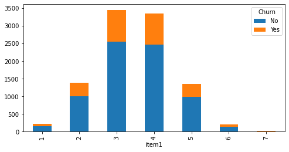

```python
plot_overlay(target,'item1',4,8)
```

```python
#plot_overlay(target,'County',4,8)
```

```python
#plot_overlay(target,'City',4,8)
```

```python
#plot_overlay(target,'Zip',4,8)
```

### =====Stop Here======

Before proceeding, understand which of the existing columns will not be affecting the PCA analysis. Remove those columns using the following section. Then, proceed to conduct the PCA.

### Encode categorical data

```python
# use sklearn to convert categorical data to numeric values
label_encoder = preprocessing.LabelEncoder()
```

```python
# encode categorical data columns
df_cat = df.select_dtypes(include='object')
cat_cols = df_cat.columns
print(cat_cols)
for c in cat_cols:
    df[c] = label_encoder.fit_transform(df[c])
```

```
Index(['Customer_id', 'City', 'State', 'County', 'Area', 'Timezone', 'Job',
       'Education', 'Employment', 'Marital', 'Gender', 'Churn', 'Techie',
       'Contract', 'Port_modem', 'Tablet', 'InternetService', 'Phone',
       'Multiple', 'OnlineSecurity', 'OnlineBackup', 'DeviceProtection',
       'TechSupport', 'StreamingTV', 'StreamingMovies', 'PaperlessBilling',
       'PaymentMethod'],
      dtype='object')
```

### Refresh Numeric Data

```python
numeric = df.select_dtypes(include='number') # numerical
numeric.info()
```

```
<class 'pandas.core.frame.DataFrame'>
RangeIndex: 10000 entries, 0 to 9999
Data columns (total 51 columns):
 #   Column                Non-Null Count  Dtype
---  ------                --------------  -----
 0   CaseOrder             10000 non-null  int64
 1   Customer_id           10000 non-null  int32
 2   City                  10000 non-null  int32
 3   State                 10000 non-null  int32
 4   County                10000 non-null  int32
 5   Zip                   10000 non-null  int64
 6   Lat                   10000 non-null  float64
 7   Lng                   10000 non-null  float64
 8   Population            10000 non-null  int64
 9   Area                  10000 non-null  int32
```

[output cut: 43 more lines]

### Drop Columns

```python
# drop columns from data
def drop_col_from_data(c):
    if c in numeric.columns:
        numeric.drop(columns = c, inplace=True)
drop_cols = ['Customer_id', 'CaseOrder',
             'Lat','Lng','item1','item2','item3',
            'item4','item5','item6','item7','item8']
for c in drop_cols:
    drop_col_from_data(c)
numeric.info()
```

```
<class 'pandas.core.frame.DataFrame'>
RangeIndex: 10000 entries, 0 to 9999
Data columns (total 39 columns):
 #   Column                Non-Null Count  Dtype
---  ------                --------------  -----
 0   City                  10000 non-null  int32
 1   State                 10000 non-null  int32
 2   County                10000 non-null  int32
 3   Zip                   10000 non-null  int64
 4   Population            10000 non-null  int64
 5   Area                  10000 non-null  int32
 6   Timezone              10000 non-null  int32
 7   Job                   10000 non-null  int32
 8   Children              10000 non-null  float64
 9   Age                   10000 non-null  float64
```

[output cut: 31 more lines]

### Revised Coorelation Matrix

This revised coorelation matrix contains all numeric data, including all of the translated categorical data.

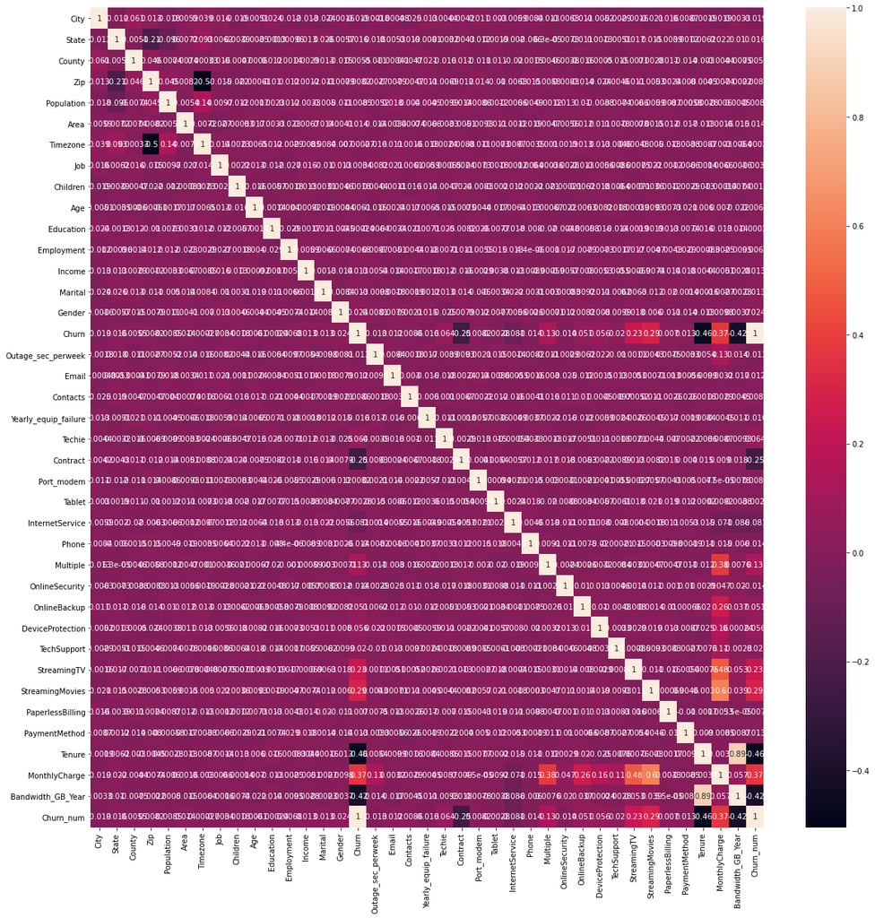

```python
plt.figure(figsize=(20,20))
sns.heatmap(numeric.corr(), annot=True, annot_kws={"size":10})
```

### Revised Coorelation Matrix

Now, refresh the coorelation matrix with just those columns that were indicated above.

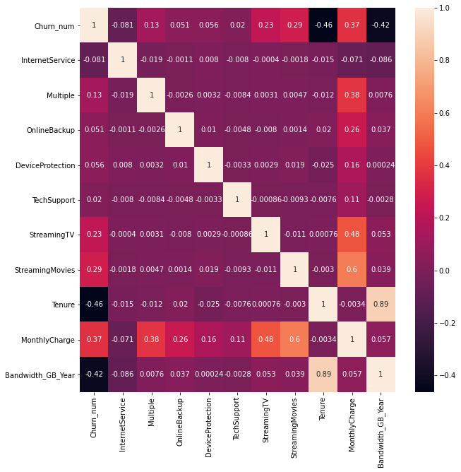

```python
df_heatmap = df[['Churn_num', 'InternetService','Multiple',
            'OnlineBackup','DeviceProtection','TechSupport',
                'StreamingTV','StreamingMovies','Tenure','MonthlyCharge',
                'Bandwidth_GB_Year']]
plt.figure(figsize=(10,10))
sns.heatmap(df_heatmap.corr(), annot=True, annot_kws={"size":10})
```

### Export Numerical Data

```python
important_cols = ['InternetService','Multiple',
            'OnlineBackup','DeviceProtection','TechSupport',
                'StreamingTV','StreamingMovies','Tenure','MonthlyCharge',
                'Bandwidth_GB_Year']
important = numeric[important_cols]
important.info()
```

```
<class 'pandas.core.frame.DataFrame'>
RangeIndex: 10000 entries, 0 to 9999
Data columns (total 10 columns):
 #   Column             Non-Null Count  Dtype
---  ------             --------------  -----
 0   InternetService    10000 non-null  int32
 1   Multiple           10000 non-null  int32
 2   OnlineBackup       10000 non-null  int32
 3   DeviceProtection   10000 non-null  int32
 4   TechSupport        10000 non-null  int32
 5   StreamingTV        10000 non-null  int32
 6   StreamingMovies    10000 non-null  int32
 7   Tenure             10000 non-null  float64
 8   MonthlyCharge      10000 non-null  float64
 9   Bandwidth_GB_Year  10000 non-null  float64
dtypes: float64(3), int32(7)
memory usage: 507.9 KB
```

```python
# export numerical data to csv file
important.to_csv('churn_important_data.csv', index = False)
```

### Normalize data

```python
# read in numeric data
numeric = pd.read_csv('churn_important_data.csv')
normal = ( numeric - numeric.mean() ) / numeric.std()
normal.info() # show types and counts
```

```
<class 'pandas.core.frame.DataFrame'>
RangeIndex: 10000 entries, 0 to 9999
Data columns (total 10 columns):
 #   Column             Non-Null Count  Dtype
---  ------             --------------  -----
 0   InternetService    10000 non-null  float64
 1   Multiple           10000 non-null  float64
 2   OnlineBackup       10000 non-null  float64
 3   DeviceProtection   10000 non-null  float64
 4   TechSupport        10000 non-null  float64
 5   StreamingTV        10000 non-null  float64
 6   StreamingMovies    10000 non-null  float64
 7   Tenure             10000 non-null  float64
 8   MonthlyCharge      10000 non-null  float64
 9   Bandwidth_GB_Year  10000 non-null  float64
dtypes: float64(10)
memory usage: 781.4 KB
```

### Scree Plot

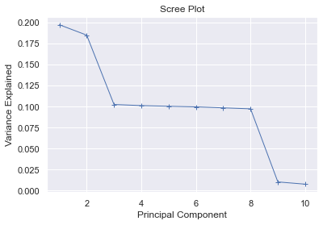

```python
# create pca scree plot
sns.set(font_scale=1)
pca = PCA(n_components=normal.shape[1])
pca.fit(normal)
PC_values = np.arange(pca.n_components_) + 1
plt.plot(PC_values, pca.explained_variance_ratio_, 'b+-', linewidth=1)
plt.title('Scree Plot')
plt.xlabel('Principal Component')
plt.ylabel('Variance Explained')
plt.show()
```

### Projected Dimensions

```python
from sklearn.decomposition import PCA
pca = PCA(2)  # project from 64 to 2 dimensions
projected = pca.fit_transform(normal)
print(normal.shape)
print(projected.shape)
```

```
(10000, 10)
(10000, 2)
```

### Cummulative Explained Variance

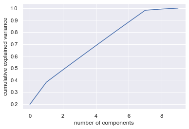

```python
# create pca scree plot cum
pca = PCA().fit(normal)
plt.plot(np.cumsum(pca.explained_variance_ratio_))
plt.xlabel('number of components')
plt.ylabel('cumulative explained variance');
```

### Display Table of Explained Variance Ratios

```python
# display list of explained variance
pca.explained_variance_ratio_
```

```
array([0.19738218, 0.18504168, 0.10249871, 0.1011845 , 0.10037063,
       0.09966612, 0.09849835, 0.09735595, 0.01034291, 0.00765898])
```

### Calculate Eigenvalues

```python
# create list of eigenvalues
matrix = np.dot(normal.T, normal) / numeric.shape[0]
eigenvalues = [np.dot(eigenvector.T, np.dot(matrix, eigenvector)) for eigenvector in pca.components_]
```

### Plot Eigenvalues

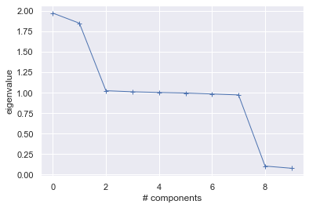

```python
# plot eigenvalues
plt.plot(eigenvalues, 'b+-', linewidth=1)
plt.xlabel('# components')
plt.ylabel('eigenvalue')
plt.show()
```

### Highlighted Component Matrix

```python
# display list of component values
values = pd.DataFrame(pca.components_.T, index=numeric.columns)
#values.loc['Total',:]= values.sum(axis=0) # col totals
#values.loc[:,'Total'] = values.sum(axis=1) # row totals
values.round(3)
values.style.highlight_max(color = 'lightgreen', axis = 0)
```

|  | 0 | 1 | 2 | 3 | 4 | 5 | 6 | 7 | 8 | 9 |
| --- | --- | --- | --- | --- | --- | --- | --- | --- | --- | --- |
| InternetService | -0.093093 | 0.019111 | 0.440199 | 0.521085 | -0.190498 | 0.051257 | -0.213081 | 0.660452 | -0.035135 | 0.062544 |
| Multiple | 0.212073 | 0.209183 | -0.330930 | -0.458311 | -0.300607 | -0.155148 | 0.166120 | 0.605550 | -0.096014 | -0.271594 |
| OnlineBackup | 0.167936 | 0.101914 | 0.353798 | -0.076851 | 0.330042 | -0.801807 | -0.190370 | -0.043747 | -0.063102 | -0.190717 |
| DeviceProtection | 0.088600 | 0.113585 | 0.429874 | 0.074647 | 0.046965 | 0.056558 | 0.877249 | -0.034895 | -0.024244 | -0.110042 |
| TechSupport | 0.051989 | 0.060787 | -0.323911 | 0.192150 | 0.833763 | 0.189219 | 0.073220 | 0.326053 | -0.032572 | -0.089808 |
| StreamingTV | 0.285758 | 0.220526 | -0.387887 | 0.656876 | -0.252017 | -0.153347 | 0.042580 | -0.244306 | -0.101785 | -0.359001 |
| StreamingMovies | 0.349941 | 0.302715 | 0.360359 | -0.193880 | 0.056619 | 0.516428 | -0.335940 | -0.144736 | -0.144073 | -0.440445 |
| Tenure | 0.433600 | -0.554829 | 0.037488 | 0.026821 | -0.015094 | 0.026721 | -0.001002 | 0.081538 | 0.663873 | -0.231760 |
| MonthlyCharge | 0.537836 | 0.457980 | -0.007877 | 0.013194 | 0.008536 | -0.002464 | -0.021313 | 0.004776 | 0.260591 | 0.657486 |
| Bandwidth_GB_Year | 0.475616 | -0.520620 | 0.006765 | 0.007192 | -0.005805 | 0.021695 | 0.026623 | 0.019109 | -0.666456 | 0.238545 |

## Part IV: Supporting Documents

### G. References

#### Getting Started

https://docs.anaconda.com/anaconda/install/windows/

https://jupyter-contrib-nbextensions.readthedocs.io/en/latest/install.html

https://jupyter-contrib-nbextensions.readthedocs.io/en/latest/install.html#install-the-python-package

https://kegui.medium.com/change-jupyter-notebook-startup-folder-windows-608dfcfdc104

(STO21) Stoltenber, S. (2021, April 26). Styling a Jupyter Notebook. Retrieved from https://skelouse.github.io/styling_a_jupyter_notebook

#### Research Question

(WGU21) WGU.edu (2021, April 26). Data Files and Associated Dictionary Files. Retrieved from https://access.wgu.edu/ASP3/aap/content/kgj47f8gj49f8du49d3k.html

### Principal Component Analysis (PCA)

https://sebastianraschka.com/Articles/2014_pca_step_by_step.html

https://pub.towardsai.net/principal-component-analysis-pca-with-python-examples-tutorial-67a917bae9aa

https://www.districtdatalabs.com/principal-component-analysis-with-python

https://www.edureka.co/blog/principal-component-analysis/

https://jakevdp.github.io/PythonDataScienceHandbook/05.09-principal-component-analysis.html

https://www.geeksforgeeks.org/principal-component-analysis-with-python/

https://stackoverflow.com/questions/13224362/principal-component-analysis-pca-in-python

https://www.machinelearningplus.com/machine-learning/principal-components-analysis-pca-better-explained/

https://www.statsmodels.org/stable/contingency_tables.html